## —

I would like to tell that I couldn’t do this study with the asked method. I was unable to create loops to renew the data and predict two day prior. I first tried to go forward with the data in hourly form. But this was much harder. Then I tried to create model for daily data. I was unsuccessful once again. At last minute effort I made predictions for the December 2020- January 2021 period.

# IE 360 FINAL

## Forecasting Solar Production Data With Time Series Analysis and Regression

Ömer Anıl Usta - IE360 - Fall20 - Final 07/02/2020

## 1.Introduction

This study takes data from Solar Power Production from CINGILLI GES solar power plant. The data is in hourly form and includes measures from October 10th 2019 until February 2nd 2021. The goal is to come up with models using time series analysis and regression for forecasting solar power production for the period December 1st 2020 to January 31st 2021. The predictions are to be made two day prior, which means the model is suppose to predict productions for two days later.

Hourly measures of temperature, downward shortwave radiation flux, cloud cover percentage are also included in the data. Measurements of these three data types from 4 different locations are given. These measures will be used to create regression models.

## 2.Analysis

The data is taken from [EPİAŞ](https://seffaflik.epias.com.tr/transparency/tuketim/gerceklesen-tuketim/gercek-zamanli-tuketim.xhtml) in hourly form. Data is turned into daily total form by summing hourly data for every day. This way it will be easier to analyze the data.

[figure not shown]

```r
ggplot(prod)+geom_line(aes(x=Date, y=daily_total), colour="cornflowerblue")+
  labs(title = "Daily Mean of Hourly Electricity Usage in Turkey in 2017-2021",
       x = "Time",
       y = "Electricity Consumption")
```

It is clearly seen that there is seasonality. Solar production drops in winter time and rises in summer.

The seasonality is one reason that removes the stationarity. The mean of the data doesn’t look stationary. The variance on the other hand looks more consistent. In summer-fall period the variance seems to be lover that usual.

Autocorrelation function is plotted to analyse lags in the daily data.

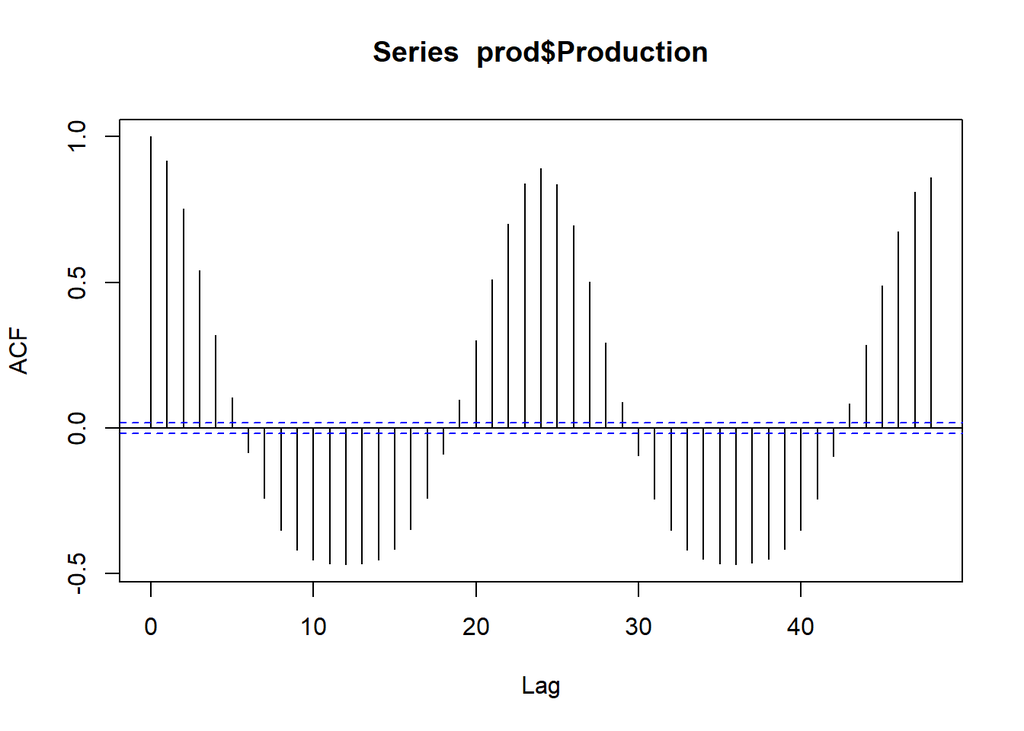

```r
prod <-data.table(read.csv("C:/Users/lenovo/Desktop/production.csv"))

prod[,Date:=as.Date(Date,"%Y-%m-%d")]
acf(prod$Production, lag.max = 48)
```

Autocorrelation function plot shows lag at 24. Which means a daily lag. This is expected.

## 2.A.Time Series Analysis

Firstly time series analysis for the data is asked. The data will be handled in hourly form. To apply time series analysis to the data it needs to be stationary. To test the stationarity KPSS test is conducted below.

```r
prod$Production%>% ur.kpss() %>% summary()
```

```
##
## #######################
## # KPSS Unit Root Test #
## #######################
##
## Test is of type: mu with 13 lags.
##
## Value of test-statistic is: 2.9377
##
## Critical value for a significance level of:
##                 10pct  5pct 2.5pct  1pct
## critical values 0.347 0.463  0.574 0.739
```

As you can see the test statistic value is much higher than critical values. Hence the stationarity isn’t achieved.

From the autocorrelation function lag 24 was correlated. Therefore when turning the data from data table from into time series from frequency 24 is used.

Time Series decomposition for solar production is conducted to achieve stationarity.

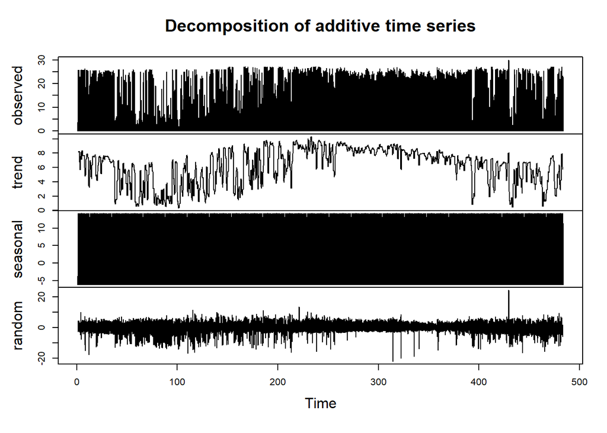

```r
prod_ts = ts(na.omit(prod$Production), frequency=24)
prod_decomp = decompose(prod_ts)
plot(prod_decomp)
```

Seasonality and trend terms of the data are substracted from the values to calculate the random term. Random term is to be used while coming up with a model if it’s stationary. First the plot of random term is analyzed.

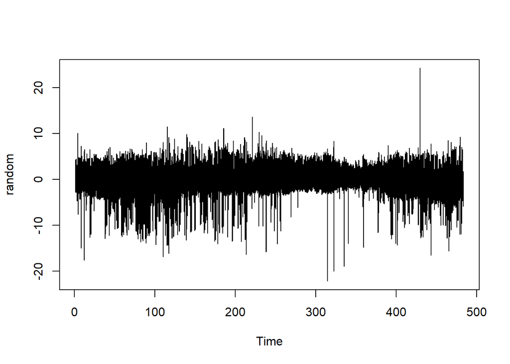

```r
random<-prod_decomp$random
ts.plot(random)
```

Random values look to be scatterede around 0. Then KPSS test is conducted to random term.

```r
random%>% ur.kpss() %>% summary()
```

```
##
## #######################
## # KPSS Unit Root Test #
## #######################
##
## Test is of type: mu with 13 lags.
##
## Value of test-statistic is: 4e-04
##
## Critical value for a significance level of:
##                 10pct  5pct 2.5pct  1pct
## critical values 0.347 0.463  0.574 0.739
```

Test statistic values is very small. Which says the random term is stationary. Therefore the random term can be used to create an ARIMA model. auto.arima function is used to find the most fitting ARIMA model.

```r
fitted=auto.arima(random,seasonal=F,trace=T)
```

```
##
##  Fitting models using approximations to speed things up...
##
##  ARIMA(2,0,2)            with non-zero mean : Inf
##  ARIMA(0,0,0)            with non-zero mean : 62604.01
##  ARIMA(1,0,0)            with non-zero mean : 52482.77
##  ARIMA(0,0,1)            with non-zero mean : 55421.76
##  ARIMA(0,0,0)            with zero mean     : 62602.01
##  ARIMA(2,0,0)            with non-zero mean : 51865.81
##  ARIMA(3,0,0)            with non-zero mean : 51776.07
##  ARIMA(4,0,0)            with non-zero mean : 51743
##  ARIMA(5,0,0)            with non-zero mean : 51692.7
##  ARIMA(5,0,1)            with non-zero mean : Inf
##  ARIMA(4,0,1)            with non-zero mean : Inf
##  ARIMA(5,0,0)            with zero mean     : 51690.7
##  ARIMA(4,0,0)            with zero mean     : 51741
##  ARIMA(5,0,1)            with zero mean     : Inf
##  ARIMA(4,0,1)            with zero mean     : Inf
##
##  Now re-fitting the best model(s) without approximations...
##
##  ARIMA(5,0,0)            with zero mean     : 51688.68
##
##  Best model: ARIMA(5,0,0)            with zero mean
```

ARIMA model (5,0,0) is returned as the most fitting model for predicting the random term.

```r
model<-arima(random, order=c(5,0,0))
print(model)
```

```
##
## Call:
## arima(x = random, order = c(5, 0, 0))
##
## Coefficients:
##          ar1      ar2      ar3     ar4      ar5  intercept
##       0.9089  -0.1553  -0.0487  0.0063  -0.0678    -0.0005
## s.e.  0.0093   0.0126   0.0126  0.0126   0.0093     0.0589
##
## sigma^2 estimated as 5.1:  log likelihood = -25838.34,  aic = 51690.68
```

```r
prod <-data.table(read.csv("C:/Users/lenovo/Desktop/production.csv"))
prod[,Date:=as.Date(Date,"%Y-%m-%d")]
prod<-prod[10058:11568,]
prod<-prod[,1:3]

predicted<-as.data.table(cbind(prod,model_forecast))
```

## 2.B.Regression

The additional measures are used to create a different model. Below you can see the regression model for the data below.

```r
prod <-data.table(read.csv("C:/Users/lenovo/Desktop/production.csv"))
prod[,Date:=as.Date(Date,"%Y-%m-%d")]
prod[,trend:=1:.N]

fit <- lm(prod$Production~0+as.factor(Hour)+as.factor(year(Date))
          +as.factor(month(Date))+CLOUD_LOW_LAYER_37.75_34.25
          +CLOUD_LOW_LAYER_37.75_34.5+CLOUD_LOW_LAYER_38_34.25
          +CLOUD_LOW_LAYER_38_34.5+DSWRF_37.75_34.25
          +DSWRF_37.75_34.5+DSWRF_38_34.25+DSWRF_38_34.5
          +TEMP_37.75_34.25+TEMP_37.75_34.5+TEMP_38_34.25
          + TEMP_38_34.5 ,
          data = prod)
summary(fit)
```

```
##
## Call:
## lm(formula = prod$Production ~ 0 + as.factor(Hour) + as.factor(year(Date)) +
##     as.factor(month(Date)) + CLOUD_LOW_LAYER_37.75_34.25 + CLOUD_LOW_LAYER_37.75_34.5 +
##     CLOUD_LOW_LAYER_38_34.25 + CLOUD_LOW_LAYER_38_34.5 + DSWRF_37.75_34.25 +
##     DSWRF_37.75_34.5 + DSWRF_38_34.25 + DSWRF_38_34.5 + TEMP_37.75_34.25 +
##     TEMP_37.75_34.5 + TEMP_38_34.25 + TEMP_38_34.5, data = prod)
##
## Residuals:
##      Min       1Q   Median       3Q      Max
## -24.7606  -1.1087  -0.0026   1.6826  27.9249
##
## Coefficients:
##                               Estimate Std. Error t value Pr(>|t|)
## as.factor(Hour)0             0.6171928  0.2684548   2.299 0.021519 *
## as.factor(Hour)1             0.6074609  0.2675097   2.271 0.023177 *
## as.factor(Hour)2             0.6170175  0.2671494   2.310 0.020926 *
## as.factor(Hour)3             0.6051667  0.2665998   2.270 0.023229 *
## as.factor(Hour)4             0.5788428  0.2640735   2.192 0.028401 *
## as.factor(Hour)5             0.5816301  0.2633800   2.208 0.027241 *
## as.factor(Hour)6             0.8688073  0.2627213   3.307 0.000946 ***
## as.factor(Hour)7             2.5678030  0.2589273   9.917  < 2e-16 ***
## as.factor(Hour)8             7.0492463  0.2551764  27.625  < 2e-16 ***
## as.factor(Hour)9            12.4423888  0.2537324  49.037  < 2e-16 ***
## as.factor(Hour)10           11.5876599  0.2739901  42.292  < 2e-16 ***
## as.factor(Hour)11           12.6491614  0.2859867  44.230  < 2e-16 ***
## as.factor(Hour)12           11.8107382  0.2974778  39.703  < 2e-16 ***
## as.factor(Hour)13           10.4126665  0.3065463  33.968  < 2e-16 ***
## as.factor(Hour)14            8.5829707  0.3131544  27.408  < 2e-16 ***
## as.factor(Hour)15            5.5340240  0.3165505  17.482  < 2e-16 ***
## as.factor(Hour)16            2.6248591  0.3005832   8.733  < 2e-16 ***
## as.factor(Hour)17           -1.2610376  0.2957857  -4.263 2.03e-05 ***
## as.factor(Hour)18           -2.9626802  0.2910502 -10.179  < 2e-16 ***
## as.factor(Hour)19           -2.7642914  0.2867990  -9.638  < 2e-16 ***
## as.factor(Hour)20           -2.0831649  0.2819047  -7.390 1.57e-13 ***
## as.factor(Hour)21           -1.7388122  0.2749934  -6.323 2.66e-10 ***
## as.factor(Hour)22            0.6114212  0.2716181   2.251 0.024402 *
## as.factor(Hour)23            0.5940911  0.2695965   2.204 0.027570 *
## as.factor(year(Date))2020    0.5039824  0.1086234   4.640 3.53e-06 ***
## as.factor(year(Date))2021    1.0517897  0.2096489   5.017 5.33e-07 ***
```

[output cut: 14 more lines]

```
## CLOUD_LOW_LAYER_38_34.5     -0.0023810  0.0026806  -0.888 0.374431
## DSWRF_37.75_34.25            0.0041715  0.0018124   2.302 0.021375 *
## DSWRF_37.75_34.5             0.0044823  0.0016243   2.760 0.005796 **
## DSWRF_38_34.25               0.0009294  0.0015076   0.616 0.537596
## DSWRF_38_34.5                0.0060942  0.0012821   4.753 2.02e-06 ***
## TEMP_37.75_34.25            -1.0033659  0.0605634 -16.567  < 2e-16 ***
## TEMP_37.75_34.5              0.6808152  0.0584486  11.648  < 2e-16 ***
## TEMP_38_34.25                0.3459031  0.0598401   5.780 7.64e-09 ***
## TEMP_38_34.5                 0.0338455  0.0449254   0.753 0.451243
## ---
## Signif. codes:  0 '***' 0.001 '**' 0.01 '*' 0.05 '.' 0.1 ' ' 1
##
## Residual standard error: 3.484 on 11543 degrees of freedom
## Multiple R-squared:  0.8994, Adjusted R-squared:  0.8989
## F-statistic:  2105 on 49 and 11543 DF,  p-value: < 2.2e-16
```

Most of the additional data is significant in the model. And the model looks to be fit. p-value is low and R-squared is adequate.

This model is used to make another prediction.

```r
prod[,fitted:=fitted(fit)]
predicted<-as.data.table(cbind(predicted,prod$fitted[10058:11568]))
```

## 3.Comparison

```r
accuracy <- function(actual, forecasted){
  n=length(actual)
  error = actual-forecasted
  mean=mean(actual)
  sd=sd(actual)
  bias = sum(error)/sum(actual)
  mape = sum(abs(error/actual))/n
  mad = sum(abs(error))/n
  wmape = mad/mean
  df = data.frame(n,mean,sd,bias,mape,mad,wmape)
  return(df)
}

accuracy(predicted$Production, predicted$V2)
```

```
##      n     mean       sd       bias mape      mad     wmape
## 1 1511 4.810119 8.220798 0.02804659  Inf 2.755889 0.5729357
```

The the accuracy test for the regression model.

```r
accuracy(predicted$Production, predicted$x)
```

```
##      n     mean       sd        bias mape      mad     wmape
## 1 1511 4.810119 8.220798 0.001903304  Inf 2.996573 0.6229728
```

## 4.Conclusion

### Appendices

##### You can read the code from here.